# 建立你的 R 語言開發環境

郭耀仁

2017-06-26

## 我們會使用兩個工具

- R
- RStudio

## 安裝 R(OS X)

- 從 The Comprehensive R Archive Network（[CRAN](https://cran.r-project.org/)）下載 .dmg 檔進行安裝

## 安裝 R(Windows)

- 從 The Comprehensive R Archive Network（[CRAN](https://cran.r-project.org/)）下載 .exe 檔進行安裝

## 安裝 RStudio(OS X)

- 從 [RStudio](https://www.rstudio.com/products/rstudio/download3/) 下載 .pkg 檔來進行安裝

## 安裝 RStudio(Windows)

- 從 [RStudio](https://www.rstudio.com/products/rstudio/download3/) 下載 .exe 檔來進行安裝

## 第一次執行 RSudio

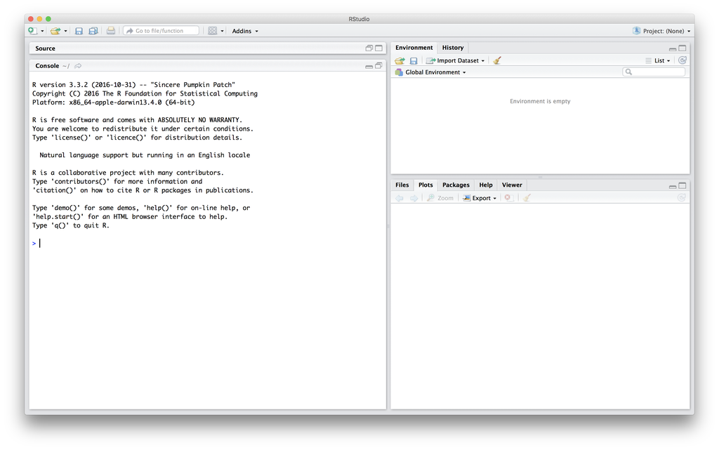

## 新增一個 R 程式

[figure not shown]

## 完整的四個區塊

- 來源（Source）：位於左上角，編寫程式的區塊
- 命令列（Console）：位於左下角，執行程式的區塊
- 環境與歷史：位於右上角
- 檔案、圖形、套件、查詢與預覽器：位於右下角

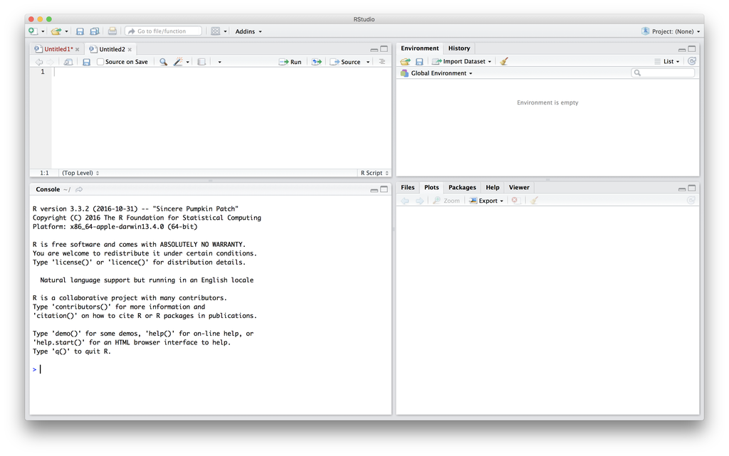

## 第一個函數 `q()`

- 在命令列（Console）輸入 `q()` 可以離開 RStudio

## 安裝 Git(OS X)

- OS X 內建 Git，不需要進行安裝
- 或者至 [git](https://git-scm.com/download/mac) 下載 .dmg 檔來進行安裝

## 安裝 Git(Windows)

- 至 [git](https://git-scm.com/download/win) 下載 .exe 檔來進行安裝

## 申請 GitHub 帳號

- 至 [GitHub](https://github.com/) 申請一個帳戶

## 基本的命令列指令

| 指令 | 說明 |
| --- | --- |
| cd | 切換目錄 |
| pwd | 取得目前所在的位置 |
| ls | 列出目前的檔案列表 |
| mkdir | 建立新的目錄 |
| touch | 建立檔案 |
| cp | 複製檔案 |
| mv | 移動檔案 |
| rm | 刪除檔案 |

## 基本的命令列指令（2）

- 打開 Git Bash
- 練習前一頁投影片的命令列指令

## 設定 Git

- 告訴 Git 你的帳戶與電子信箱
- 在終端機輸入：

```
git config --global user.name "YOUR NAME"
git config --global user.email YOUR EMAIL ADDRESS
```

## 建立一個遠端 repository

- 至 [GitHub](https://github.com/) 建立一個遠端 repository
- 將新建的 repository 複製回本機資料夾

```
cd ~
git clone "YOUR REPOSITORY URL"
```

## 將本機新增的檔案推到遠端 repository

- 在本機資料夾新增檔案
- 存檔後在命令列輸入：

```
git add .
git commit -m "first commit"
git push
```

- `git commit -m` 後面的訊息可以自訂

## 練習

- 上傳兩個檔案至 GitHub
  - RStudio 螢幕截圖
  - hello_world.R